# Actividad Semanal N°1

Diego Bernal: diego.bernals@usm.cl

## Pregunta N°1

Primero cargamos las bibliotecas que utilizaremos.

```r
library(tidyverse) #meta-package
library(moments) # Para calcular el skewness y kurtosis
```

Simularemos 100 valores con una distribución normal con media = 22 y varianza = 16, para esto utilizaremos la función `rnorm()` la cual requiere como argumentos la cantidad de numeros que queremos simular, la media de la población y su desviación estandar.

```r
set.seed(707) #Siempre agreguenlo cuando quieren que su ejemplo sea reproducible por otros.
vec_norm <- round(rnorm(100, mean =22, sd = 4),2)
datos <- data.frame(datos_norm = vec_norm) #Lo guardamos en un df
head(datos)
```

|  | datos_norm |
| --- | --- |
| 1 | 16.87 |
| 2 | 19.53 |
| 3 | 24.80 |
| 4 | 26.56 |
| 5 | 18.71 |
| 6 | 17.85 |

## Pregunta N°2

Para realizar esta tarea primero calcularemos el numero optimo de bins, como lo utilizaremos mas veces crearemos una función que reciba com oargumento un vector.

```r
bins_op <- function(datos) {
  Q1 <- quantile(datos, probs = 0.25, type = 6)[[1]]
  Q3 <- quantile(datos, probs = 0.75, type = 6)[[1]]
  IQR <- Q3 - Q1
  h <- 2 * IQR * length(datos)^(-1/3)
  bins <- (max(datos) - min(datos)) / h

  return(round(bins,0))
}
```

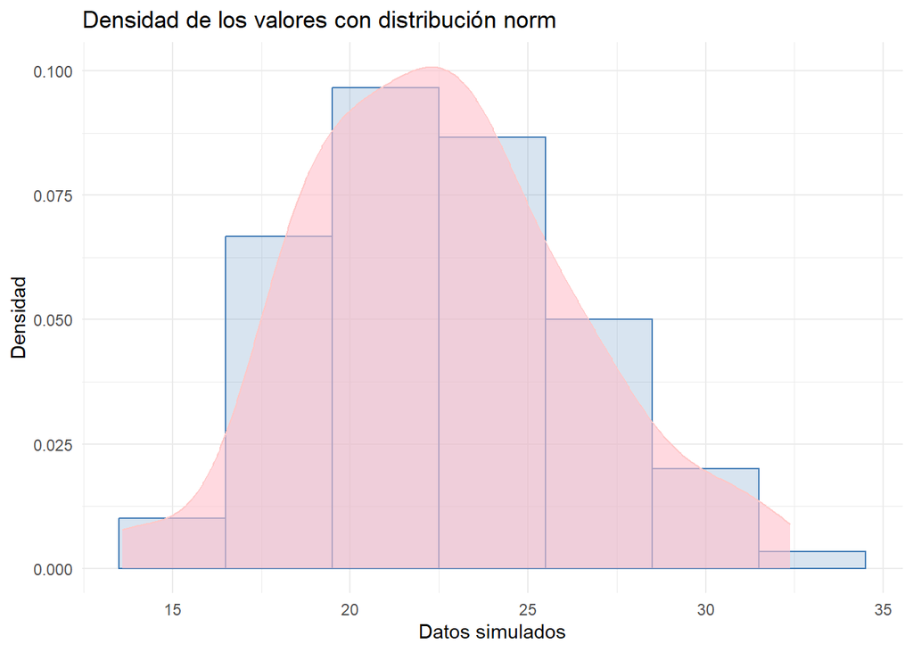

```r
ggplot(datos, aes(x = datos_norm)) +
  geom_histogram(aes(y = ..density..), colour = "#3c78b4", fill = "#3c78b4", alpha = 0.2, bins=bins_op(datos$datos_norm),binwidth= 3)+
  geom_density(alpha = .6, fill = "pink", colour = '#ffc8c8') +
  theme_minimal() + labs(title = "Densidad de los valores con distribución norm",
                         x="Datos simulados",
                         y="Densidad")
```

```r
round(skewness(datos$datos_norm),1)
```

```
## [1] 0.3
```

```r
round(kurtosis(datos$datos_norm), 1)
```

```
## [1] 3
```

## Pregunta N°3

Para realizar el muestreo aleatorio utilizaremos la función `sample` la cual toma una muestra de un determinado conjunto de datos, especificamente un data frame, teniendo dos opciones con reemplazo o sin reemplazo, en nuestro caso trbajaremos sin reemplazo. `sample(x, size, replace = FALSE)` los argumentos que le podemos pasar a la función son los siguientes;

1. *x* = Puede ser un vector de uno o mas elementos
2. *size* = tamaño de la muestra
3. *replace* = Si queremos realizar el muestreo con reemplazo.

```r
set.seed(707)
N <- nrow(datos)
n <- 20
units <- sample(N, size = n, replace = FALSE)
mysample <- datos[units, ]
```

Ahora generaremos 100 muestras aleatorias de tamaño 20, para esto tendremos que generar un iterador, el cual realice el muestreo y a ese muestreo le calcule la media y desviación estadar a cada muestra y los vaya guardando en vectores, despues los llevamos a un data frame para poder graficarlos.

```r
n <- 20
n_samples <- 100

ms <- ds_ms <- numeric(length = n_samples)
N <- nrow(datos)

set.seed(707)

for (i in 1:n_samples) {
  units <- sample(N, size = n, replace = FALSE)
  ms[i] <- round(mean(datos$datos_norm[units]),2)
  ds_ms[i] <- sqrt(var(datos$datos_norm[units]) / n)
}

ms_df <- data.frame(ms = ms, ds = ds_ms)
```

Amplitud optima del histograma que sigue una distribución normal

```r
h_med = round(2*3^(1/3)*(3.14)^(1/6)*sqrt(var(ms_df$ms))*nrow(ms_df)^(-1/3),2)
h_sd = round(2*3^(1/3)*(3.14)^(1/6)*sqrt(var(ms_df$ds))*nrow(ms_df)^(-1/3),2)


print(paste("La amplitud del histograma para la media es:", h_med))
```

```
## [1] "La amplitud del histograma para la media es: 0.58"
```

```r
print(paste("La amplitud del histograma para el error estandar es:", h_sd))
```

```
## [1] "La amplitud del histograma para el error estandar es: 0.1"
```

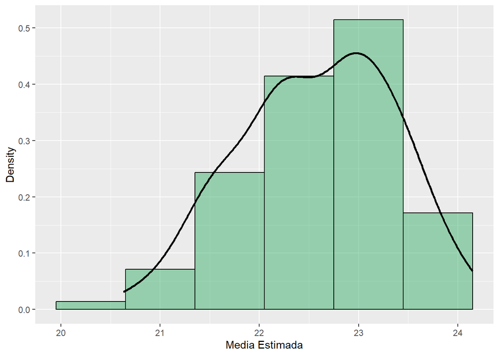

```r
ggplot(ms_df) +
  geom_histogram(aes(x = ms, y = ..density..), binwidth = 0.70, fill = "#40b16d", alpha = 0.5, colour = "black",bins = bins_op(ms_df$ms)) +
  geom_density(aes(x = ms, y = ..density..), lwd = 1) +
  scale_x_continuous(name = "Media Estimada") +
  scale_y_continuous(name = "Density")
```

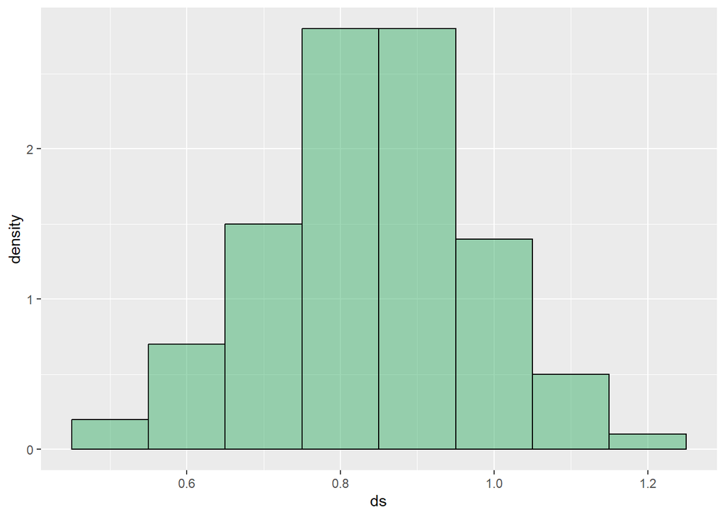

```r
ggplot(ms_df) +
  geom_histogram(aes(x = ds, y = ..density..), binwidth = 0.1, fill = "#40b16d", alpha = 0.5, colour = "black",bins = bins_op(ms_df$ds))
```

```r
mean(ms_df$ms)
```

```
## [1] 22.5771
```